# LM Sheet 3 - part 2

2. A hospital surgical unit was interested in predicting survival time in patients undergoing a particular type of liver operation. From a random sample of 54 patients, information on the patient’s survival time, blood clotting score, prognostic index, enzyme function test score and liver function test score were extracted. The data surgical.txt is available for download in Blackboard.

```r
Surgical <- read.table(file="C:/Users/Dom/Documents/GitHub/Stats Work/Year 3/Linear Models/Surgical.txt", header=TRUE) #read in data in .txt format
head(Surgical) #view first six entries of Surgical
```

|  | blood.clotting | prognostic | enzyme | liver.function | survival |
| --- | --- | --- | --- | --- | --- |
| 1 | 6.7 | 62 | 81 | 2.59 | 200 |
| 2 | 5.1 | 59 | 66 | 1.70 | 101 |
| 3 | 7.4 | 57 | 83 | 2.16 | 204 |
| 4 | 6.5 | 73 | 41 | 2.01 | 101 |
| 5 | 7.8 | 65 | 115 | 4.30 | 509 |
| 6 | 5.8 | 38 | 72 | 1.42 | 80 |

1. Fit a multiple regression model using the survival time as the response variable and the other four variables as explanatory variables.

```r
model <- lm(survival ~ blood.clotting + prognostic + enzyme + liver.function, data=Surgical) #fit full model
model
```

```
Call:
lm(formula = survival ~ blood.clotting + prognostic + enzyme +
    liver.function, data = Surgical)

Coefficients:
   (Intercept)  blood.clotting      prognostic          enzyme  liver.function
      -621.598          33.164           4.272           4.126          14.092
```

2. Conduct an F-test for the overall fit of the regression model in (a). Comment on the results.

```r
anova(model) #run F-test for full model
```

```
Analysis of Variance Table

Response: survival
               Df Sum Sq Mean Sq  F value    Pr(>F)
blood.clotting  1 155274  155274  41.6520 4.656e-08 ***
prognostic      1 305511  305511  81.9528 4.920e-12 ***
enzyme          1 470760  470760 126.2804 3.638e-15 ***
liver.function  1   4719    4719   1.2657    0.2661
Residuals      49 182667    3728
---
Signif. codes:  0 *** 0.001 ** 0.01 * 0.05 . 0.1   1
```

3. Test each of the individual regression coefficients. Do the results indicate that any of the explanatory variables can be removed from the model?

```r
summary(model)
```

```
Call:
lm(formula = survival ~ blood.clotting + prognostic + enzyme +
    liver.function, data = Surgical)

Residuals:
   Min     1Q Median     3Q    Max
-80.52 -34.68 -15.15  20.59 323.15

Coefficients:
                Estimate Std. Error t value Pr(>|t|)
(Intercept)    -621.5976    64.8004  -9.592 7.86e-13 ***
blood.clotting   33.1638     7.0173   4.726 1.97e-05 ***
prognostic        4.2719     0.5634   7.582 8.35e-10 ***
enzyme            4.1257     0.5112   8.071 1.49e-10 ***
liver.function   14.0916    12.5253   1.125    0.266
---
Signif. codes:  0 *** 0.001 ** 0.01 * 0.05 . 0.1   1

Residual standard error: 61.06 on 49 degrees of freedom
Multiple R-squared:  0.8367,    Adjusted R-squared:  0.8234
F-statistic: 62.79 on 4 and 49 DF,  p-value: < 2.2e-16
```

At the .05 significance level, the ANOVA table and the summary table for the full fitted model indicate that the intercept and the first three coefficients add significantly to the model’s explanatory ability, while liver function does not.

4. Perform the forward, backward and backward-forward variable selection using the function subset from the R package MASS. Compare the ‘best’ model selected from each stepwise method, e.g., are all the methods return the same model? If not, why is it so?

```r
library(MASS) #load MASS package
null <- lm(survival ~ 1, data=Surgical) #specify null model
full <- lm(survival ~ ., data=Surgical) #specify full model
step(null, scope = list(lower=null, upper=full), direction = "forward")
```

```
Start:  AIC=538.7
survival ~ 1

                 Df Sum of Sq     RSS    AIC
+ liver.function  1    583809  535123 500.87
+ enzyme          1    376725  742206 518.53
+ prognostic      1    343388  775543 520.91
+ blood.clotting  1    155274  963657 532.63
<none>                        1118932 538.70

Step:  AIC=500.87
survival ~ liver.function

                 Df Sum of Sq    RSS    AIC
+ prognostic      1    107007 428116 490.82
+ enzyme          1    105711 429412 490.98
<none>                        535123 500.87
+ blood.clotting  1       138 534984 502.85

Step:  AIC=490.82
survival ~ liver.function + prognostic

                 Df Sum of Sq    RSS    AIC
+ enzyme          1    162185 265931 467.11
<none>                        428116 490.82
+ blood.clotting  1      2591 425525 492.49

Step:  AIC=467.11
survival ~ liver.function + prognostic + enzyme

                 Df Sum of Sq    RSS    AIC
+ blood.clotting  1     83264 182667 448.83
<none>                        265931 467.11

Step:  AIC=448.83
survival ~ liver.function + prognostic + enzyme + blood.clotting


Call:
lm(formula = survival ~ liver.function + prognostic + enzyme +
    blood.clotting, data = Surgical)

Coefficients:
   (Intercept)  liver.function      prognostic          enzyme  blood.clotting
      -621.598          14.092           4.272           4.126          33.164
```

```r
step(full, data = Surgical, direction = "backward")
```

```
Start:  AIC=448.83
survival ~ blood.clotting + prognostic + enzyme + liver.function

                 Df Sum of Sq    RSS    AIC
- liver.function  1      4719 187385 448.20
<none>                        182667 448.83
- blood.clotting  1     83264 265931 467.11
- prognostic      1    214333 396999 488.75
- enzyme          1    242858 425525 492.49

Step:  AIC=448.2
survival ~ blood.clotting + prognostic + enzyme

                 Df Sum of Sq    RSS    AIC
<none>                        187385 448.20
- blood.clotting  1    194041 381427 484.59
- prognostic      1    313324 500709 499.28
- enzyme          1    470760 658146 514.04

Call:
lm(formula = survival ~ blood.clotting + prognostic + enzyme,
    data = Surgical)

Coefficients:
   (Intercept)  blood.clotting      prognostic          enzyme
      -659.179          38.323           4.568           4.485
```

```r
step(full, scope = list(lower=null), data=Surgical, direction = "both")
```

```
Start:  AIC=448.83
survival ~ blood.clotting + prognostic + enzyme + liver.function

                 Df Sum of Sq    RSS    AIC
- liver.function  1      4719 187385 448.20
<none>                        182667 448.83
- blood.clotting  1     83264 265931 467.11
- prognostic      1    214333 396999 488.75
- enzyme          1    242858 425525 492.49

Step:  AIC=448.2
survival ~ blood.clotting + prognostic + enzyme

                 Df Sum of Sq    RSS    AIC
<none>                        187385 448.20
- blood.clotting  1    194041 381427 484.59
- prognostic      1    313324 500709 499.28
- enzyme          1    470760 658146 514.04

Call:
lm(formula = survival ~ blood.clotting + prognostic + enzyme,
    data = Surgical)

Coefficients:
   (Intercept)  blood.clotting      prognostic          enzyme
      -659.179          38.323           4.568           4.485
```

So each method respectively gave, as the chosen optimal model: lm(formula = survival ~ liver.function + prognostic + enzyme + blood.clotting, data = Surgical) lm(formula = survival ~ blood.clotting + prognostic + enzyme, data = Surgical) lm(formula = survival ~ blood.clotting + prognostic + enzyme, data = Surgical)

These results occured due to the poor contribution liver.function makes to explanation.

5. Using the function regsubsets from the package leaps to perform the subset selection on the dataset and compare the results to the models obtained in (d). Comment on the validity of the fitted model by plotting the residuals.

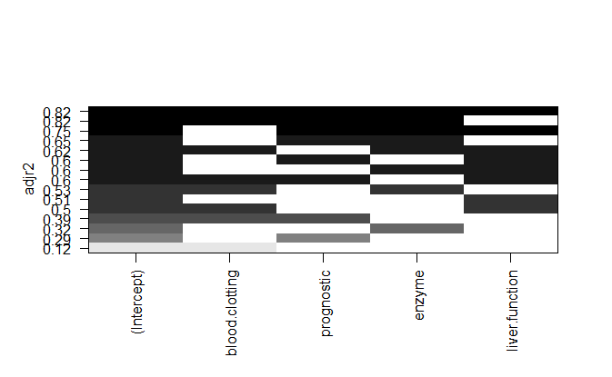

```r
library(leaps)
subset.fit <- regsubsets(survival ~., data=Surgical, nbest=10) #perform exhaustive model search
plot(subset.fit, scale = "adjr2") #plot results against adjusted R^2 measure
```

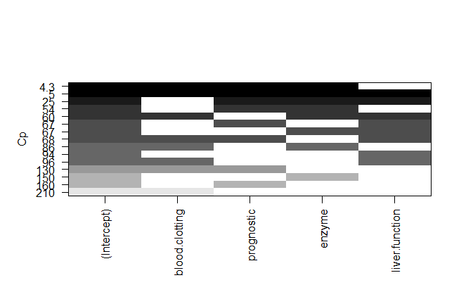

```r
plot(subset.fit, scale = "Cp") #plot against Mallow's Cp
```

The adjusted R^2 measure suggests using the full model, while Mallow’s Cp suggests omitting liver function. Both of these models were suggested by the methods employed in the previous question, implying validity in the results.

6. Use the function boxcox from the R package MASS and suggest a good transform for the response variable.

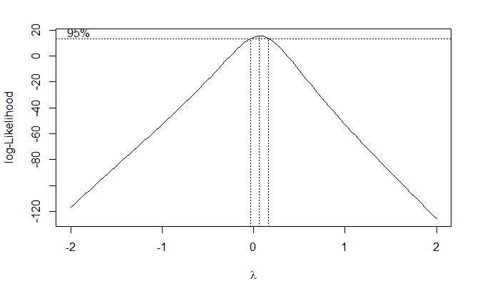

```r
bc <- boxcox(full)
```

```r
bc$x[which.max(bc$y)]
```

```
[1] 0.06060606
```

Using lambda=0 is significant at the 0.05 level, so a log transform may be appropriate.

////////////////////////////////////////////

```r
library(ISLR, lars)
head(Hitters)
```

|  | AtBat | Hits | HmRun | Runs | RBI | Walks | Years | CAtBat | CHits | CHmRun | CRuns | CRBI | CWalks | League | Division | PutOuts | Assists | Errors | Salary | NewLeague |
| --- | --- | --- | --- | --- | --- | --- | --- | --- | --- | --- | --- | --- | --- | --- | --- | --- | --- | --- | --- | --- |
| -Andy Allanson | 293 | 66 | 1 | 30 | 29 | 14 | 1 | 293 | 66 | 1 | 30 | 29 | 14 | A | E | 446 | 33 | 20 | NA | A |
| -Alan Ashby | 315 | 81 | 7 | 24 | 38 | 39 | 14 | 3449 | 835 | 69 | 321 | 414 | 375 | N | W | 632 | 43 | 10 | 475.0 | N |
| -Alvin Davis | 479 | 130 | 18 | 66 | 72 | 76 | 3 | 1624 | 457 | 63 | 224 | 266 | 263 | A | W | 880 | 82 | 14 | 480.0 | A |
| -Andre Dawson | 496 | 141 | 20 | 65 | 78 | 37 | 11 | 5628 | 1575 | 225 | 828 | 838 | 354 | N | E | 200 | 11 | 3 | 500.0 | N |
| -Andres Galarraga | 321 | 87 | 10 | 39 | 42 | 30 | 2 | 396 | 101 | 12 | 48 | 46 | 33 | N | E | 805 | 40 | 4 | 91.5 | N |
| -Alfredo Griffin | 594 | 169 | 4 | 74 | 51 | 35 | 11 | 4408 | 1133 | 19 | 501 | 336 | 194 | A | W | 282 | 421 | 25 | 750.0 | A |

```r
new.hitters <- Hitters[!is.na(Hitters$Salary),] #omit missing data
y <- new.hitters[,19]
X0 <- new.hitters[, -19]
X0$League <- as.numeric(X0$League)-1 #covert entries to binary
X0$Division <- as.numeric(X0$Division)-1
X0$NewLeague <- as.numeric(X0$NewLeague)-1
X <- scale(X0) #centre and scale
```

[figure not shown]